# STAT462 Assignment 3 - Classifying volcanic rock and Clustering seeds

Xia Yu (62380486)

David Ewing (82171165)

2025-05-28 09:01

# Appendix - Common Functions

# Question A: **Classifying volcanic rock**

*In this question, you are allowed to use any method available to you in R, either programmed yourself, or from packages of your choosing. The important thing here is that you communicate your results very well, in terms of language, illustration, and precision.*

In this question you will analyse a dataset containing volcanic rocks and their chemical composition, collected from various sites in New Zealand. You will predict whether the `Source` of a given rock sample is “Okataina” (a geographical location), or whether the sample comes from somewhere else.

Load the annotated dataset `rocks.csv`. and the unlabelled dataset `rocks_unlabelled.csv`. You will find that rows in the latter set do not contain an entry for `Source`, i.e., they are of unknown origin. Your goal will be to fill these blanks, using the techniques you have learned in this course so far. The following guidelines might be useful to consider:

- Use a classification-tree-based method (can also be random forests or boosting), and at least one additional different data mining algorithms (two tree variants are not considered “different”). Compare their performance in a suitable way.
- It will not be enough to just predict some `Source` labels for the missing data, but you will need to quantify and justify the accuracy of your predictions. It is OK if you think that your method is not perfect, but be sure to point out its limitations in this case. You will not be judged on accuracy, but on correctness of procedure, and clarity of communication.
- How exactly you prepare and work with the dataset is your choice, but follow good practice models as demonstrated in the course (for example, consider “data hygiene”, i.e., don’t test on training data etc.).
- Be brief, exact, correct, and communicate well.

# Data Loading and Preprocessing

```r
# Load required libraries
library(tidyverse)    # For data manipulation and visualization
library(readr)        # For reading CSV files
library(caret)        # For model training and preprocessing
library(knitr)        # For neat table rendering

# Load labeled and unlabeled datasets
rocks <- read_csv("../data/rocks.csv", col_types = cols(...1 = col_skip()))
rocks_unlabelled <- read_csv("../data/rocks_unlabelled.csv", col_types = cols(...1 = col_skip()))


# Inspect the structure of the datasets
# Check for missing values

skim(rocks)
```

Data summary

| Name | rocks |
| --- | --- |
| Number of rows | 330 |
| Number of columns | 12 |
| _______________________ |  |
| Column type frequency: |  |
| logical | 1 |
| numeric | 11 |
| ________________________ |  |
| Group variables | None |

**Variable type: logical**

| skim_variable | n_missing | complete_rate | mean | count |
| --- | --- | --- | --- | --- |
| okataina | 0 | 1 | 0.88 | TRU: 291, FAL: 39 |

**Variable type: numeric**

| skim_variable | n_missing | complete_rate | mean | sd | p0 | p25 | p50 | p75 | p100 | hist |
| --- | --- | --- | --- | --- | --- | --- | --- | --- | --- | --- |
| SiO2 | 0 | 1 | 75.62 | 3.24 | 51.29 | 75.23 | 76.34 | 77.26 | 78.66 | ▁▁▁▁▇ |
| TiO2 | 0 | 1 | 0.21 | 0.15 | 0.10 | 0.12 | 0.18 | 0.24 | 1.08 | ▇▁▁▁▁ |
| Al2O3 | 0 | 1 | 13.52 | 1.17 | 12.18 | 12.73 | 13.24 | 14.01 | 19.04 | ▇▃▁▁▁ |
| Fe2O3 | 0 | 1 | 1.87 | 1.31 | 0.43 | 1.32 | 1.56 | 1.88 | 11.85 | ▇▁▁▁▁ |
| MnO | 0 | 1 | 0.05 | 0.02 | 0.01 | 0.04 | 0.05 | 0.06 | 0.20 | ▇▇▁▁▁ |
| MgO | 0 | 1 | 0.37 | 0.60 | 0.07 | 0.18 | 0.24 | 0.32 | 5.63 | ▇▁▁▁▁ |
| CaO | 0 | 1 | 1.26 | 0.81 | 0.64 | 0.87 | 1.04 | 1.32 | 8.88 | ▇▁▁▁▁ |
| Na2O | 0 | 1 | 3.64 | 0.44 | 1.77 | 3.36 | 3.63 | 3.97 | 4.60 | ▁▁▅▇▃ |
| K2O | 0 | 1 | 3.44 | 0.57 | 0.60 | 3.18 | 3.54 | 3.83 | 5.15 | ▁▁▅▇▁ |
| P2O5 | 0 | 1 | 0.02 | 0.01 | 0.00 | 0.01 | 0.01 | 0.02 | 0.09 | ▇▅▁▁▁ |
| LOI | 0 | 1 | 3.53 | 0.92 | 0.19 | 3.09 | 3.64 | 4.15 | 5.88 | ▁▂▆▇▁ |

```r
skim(rocks_unlabelled)
```

Data summary

| Name | rocks_unlabelled |
| --- | --- |
| Number of rows | 30 |
| Number of columns | 11 |
| _______________________ |  |
| Column type frequency: |  |
| numeric | 11 |
| ________________________ |  |
| Group variables | None |

**Variable type: numeric**

| skim_variable | n_missing | complete_rate | mean | sd | p0 | p25 | p50 | p75 | p100 | hist |
| --- | --- | --- | --- | --- | --- | --- | --- | --- | --- | --- |
| SiO2 | 2 | 0.93 | 75.61 | 2.01 | 71.15 | 74.15 | 75.97 | 77.34 | 77.88 | ▂▃▂▇▇ |
| TiO2 | 2 | 0.93 | 0.20 | 0.08 | 0.11 | 0.14 | 0.17 | 0.27 | 0.34 | ▇▃▃▂▃ |
| Al2O3 | 2 | 0.93 | 13.79 | 1.17 | 12.45 | 12.75 | 13.67 | 14.42 | 16.63 | ▇▇▃▁▂ |
| Fe2O3 | 2 | 0.93 | 1.68 | 0.43 | 1.10 | 1.36 | 1.61 | 2.01 | 2.51 | ▇▇▃▆▃ |
| MnO | 2 | 0.93 | 0.05 | 0.01 | 0.04 | 0.04 | 0.05 | 0.05 | 0.06 | ▇▁▆▁▃ |
| MgO | 2 | 0.93 | 0.30 | 0.14 | 0.10 | 0.22 | 0.26 | 0.38 | 0.60 | ▂▇▂▁▂ |
| CaO | 2 | 0.93 | 1.31 | 0.53 | 0.76 | 0.94 | 1.08 | 1.83 | 2.55 | ▇▂▁▂▁ |
| Na2O | 2 | 0.93 | 3.48 | 0.29 | 2.93 | 3.27 | 3.54 | 3.63 | 4.15 | ▂▂▇▁▁ |
| K2O | 2 | 0.93 | 3.57 | 0.45 | 2.28 | 3.33 | 3.75 | 3.89 | 4.10 | ▁▁▃▂▇ |
| P2O5 | 2 | 0.93 | 0.01 | 0.00 | 0.01 | 0.01 | 0.01 | 0.01 | 0.03 | ▇▁▁▁▁ |
| LOI | 2 | 0.93 | 3.77 | 0.68 | 1.67 | 3.34 | 4.03 | 4.18 | 4.73 | ▁▁▅▇▆ |

We imported two datasets:

`rocks.csv`: labelled training data including the `okataina` variable.

`rocks_unlabelled.csv`: data without labels, to be predicted later.

# 🪾Tree Method: Random Forest

## RF-Tree Training

```r
# Load required packages
library(randomForest)   # For random forest classifier
library(caret)          # For cross-validation and evaluation
library(pROC)           # For AUC calculation
set.seed(62380486)      # For reproducibility

# Recode the logical target variable into valid factor labels
rocks$okataina <- factor(rocks$okataina, levels = c(FALSE, TRUE), labels = c("No", "Yes"))

# Define 10-fold cross-validation control
ctrl <- trainControl(
  method = "cv",
  number = 10,
  classProbs = TRUE,                   # Needed for AUC
  summaryFunction = twoClassSummary,  # ROC, Sens, Spec
  savePredictions = TRUE
)

# Train Random Forest model
mtry_grid <- expand.grid(mtry = 2:11)  # explicitly specified a tuning grid ranging from mtry = 2 to 11
tree.rf <- train(
  okataina ~ ., data = rocks,
  method = "rf",
  metric = "ROC",                     # AUC is the performance metric
  trControl = ctrl,
  tuneGrid = mtry_grid               # the default mtry serachign range is 3, mannually set to 10.
)

# Output model summary
print(tree.rf)
```

```
## Random Forest
##
## 330 samples
##  11 predictor
##   2 classes: 'No', 'Yes'
##
## No pre-processing
## Resampling: Cross-Validated (10 fold)
## Summary of sample sizes: 297, 297, 297, 297, 297, 296, ...
## Resampling results across tuning parameters:
##
##   mtry  ROC        Sens   Spec
##    2    0.9793103  0.400  1.0000000
##    3    0.9732759  0.450  0.9965517
##    4    0.9750000  0.500  0.9932184
##    5    0.9659770  0.525  0.9897701
##    6    0.9638218  0.500  0.9897701
##    7    0.9634195  0.525  0.9897701
##    8    0.9647126  0.500  0.9897701
##    9    0.9595402  0.525  0.9863218
##   10    0.9565230  0.475  0.9863218
##   11    0.9461782  0.475  0.9863218
##
## ROC was used to select the optimal model using the largest value.
## The final value used for the model was mtry = 2.
```

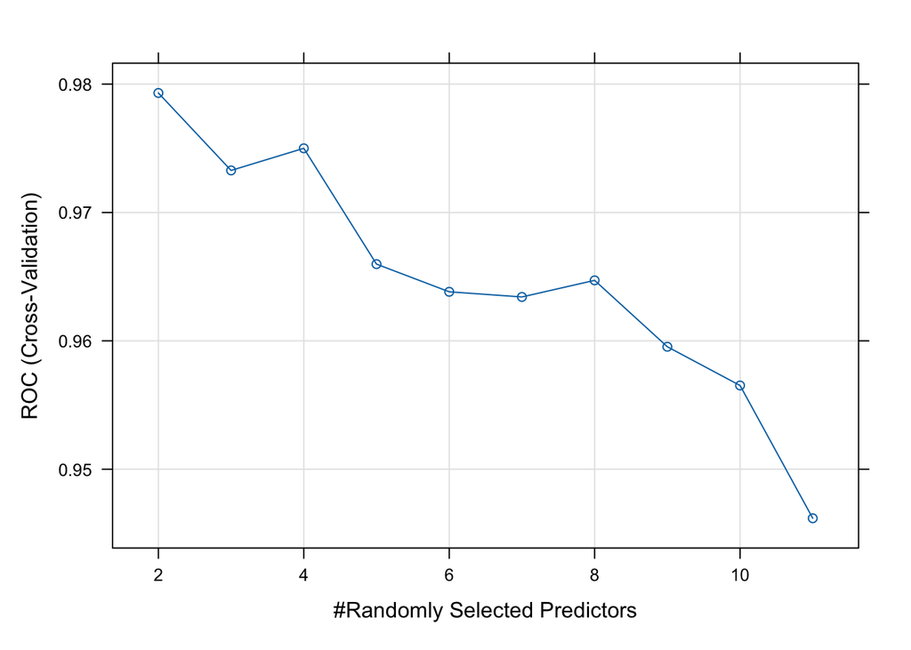

```r
plot(tree.rf)
```

The `mtry` parameter in Random Forest controls the number of predictors randomly selected at each split.

To explore the effect of the number of predictors at each split (`mtry`), we specified a tuning grid from `mtry = 2 to 11`. This allowed the model to evaluate all candidate values through 10-fold cross-validation and select the optimal setting based on the highest AUC. The expanded search space offers more detailed insights into model performance and helps avoid suboptimal defaults.

In this case, the optimal `mtry` is 2, selected from a total of `p = 11` features. By randomly selecting m features from p features, we introduced randomness into the tree-growing process. This approach increased diversity among trees, reduced correlation, and enhanced the ensemble’s ability to reduce variance(Li lecture 2025).

In this model, mtry = 2 resulted in the highest cross-validated ROC of `~0.98`, indicating the best overall discriminative performance. Therefore, it was chosen as the optimal setting.

## Confusion Matrix

```r
# Recompute confusion matrix using best cross-validated predictions
# Note: Use predictions corresponding to the best mtry model (mtry = 2)

# Filter predictions to match selected tuning parameters
best_pred <- tree.rf$pred %>%
  filter(mtry == tree.rf$bestTune$mtry)

# Generate confusion matrix
conf_matrix <- confusionMatrix(
  data = best_pred$pred,
  reference = best_pred$obs,
  positive = "Yes"  # "Yes" is the target class (Okataina)
)

# Display confusion matrix
print(conf_matrix)
```

```
## Confusion Matrix and Statistics
##
##           Reference
## Prediction  No Yes
##        No   15   0
##        Yes  24 291
##
##                Accuracy : 0.9273
##                  95% CI : (0.8937, 0.9528)
##     No Information Rate : 0.8818
##     P-Value [Acc > NIR] : 0.004544
##
##                   Kappa : 0.5243
##
##  Mcnemar's Test P-Value : 2.668e-06
##
##             Sensitivity : 1.0000
##             Specificity : 0.3846
##          Pos Pred Value : 0.9238
##          Neg Pred Value : 1.0000
##              Prevalence : 0.8818
##          Detection Rate : 0.8818
##    Detection Prevalence : 0.9545
##       Balanced Accuracy : 0.6923
##
##        'Positive' Class : Yes
##
```

## ROC Curve and AUC

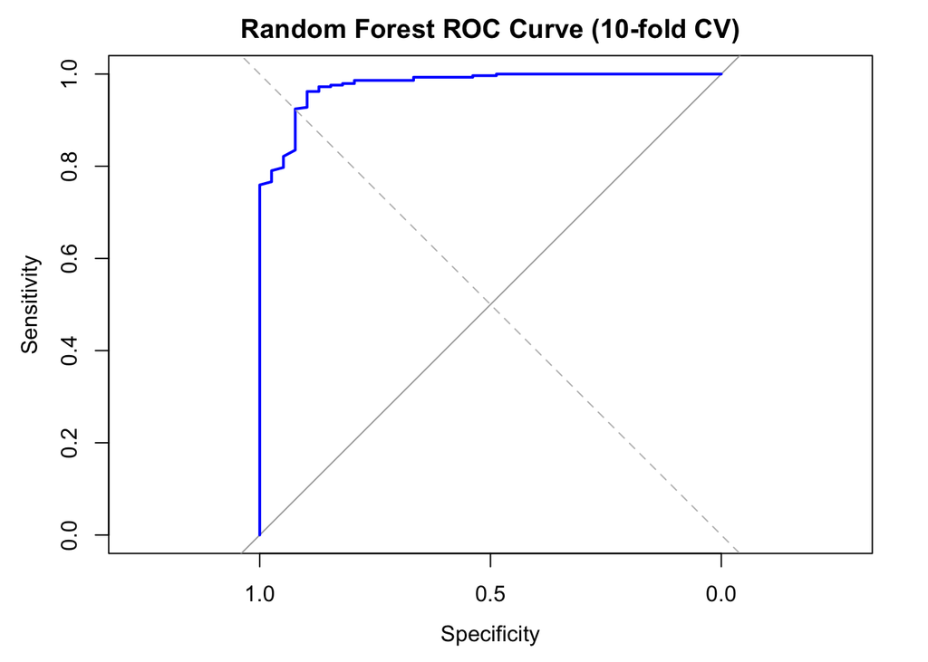

```r
# Compute ROC curve
roc_curve <- roc(
  response = best_pred$obs,
  predictor = best_pred$Yes,    # predicted probability for class "Yes"
  levels = c("No", "Yes"),
  direction = "<"
)

# Plot ROC curve
plot(roc_curve,
     col = "blue",
     lwd = 2,
     main = "Random Forest ROC Curve (10-fold CV)")
abline(a = 0, b = 1, lty = 2, col = "gray")  # diagonal reference line
```

```r
# Report AUC value
auc(roc_curve)
```

```
## Area under the curve: 0.9767
```

## Feature Importance Visualisation

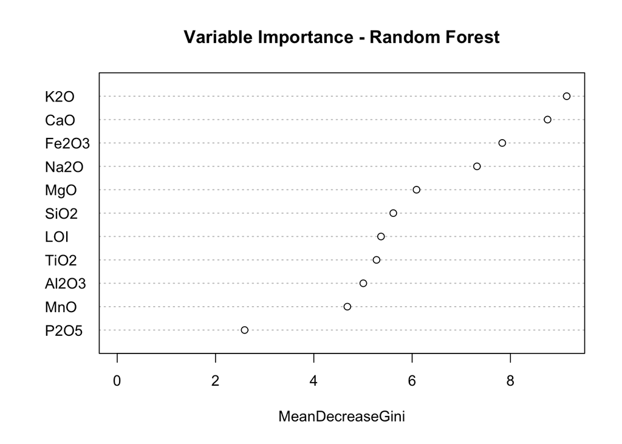

```r
# Variable importance from the caret-trained model
varImpPlot(tree.rf$finalModel, main = "Variable Importance - Random Forest")
```

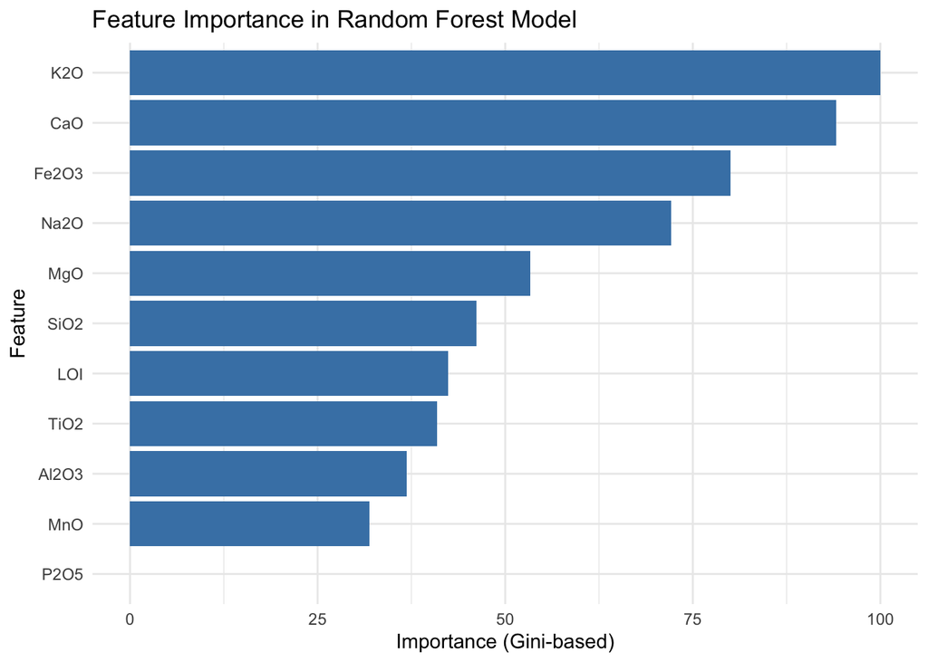

```r
# Alternatively, get numeric importance values
importance_df <- as.data.frame(varImp(tree.rf)$importance)
importance_df <- importance_df %>%
  rownames_to_column("Feature") %>%
  arrange(desc(Overall))

# Pretty barplot using ggplot2
library(ggplot2)
ggplot(importance_df, aes(x = reorder(Feature, Overall), y = Overall)) +
  geom_col(fill = "steelblue") +
  coord_flip() +
  labs(title = "Feature Importance in Random Forest Model",
       x = "Feature", y = "Importance (Gini-based)") +
  theme_minimal()
```

We visualized feature importance using both `varImpPlot()` from the `randomForest` package and a custom `ggplot2` barplot based on `caret::varImp()`. While both methods rank features similarly, they differ in the scale of the x-axis.

`varImpPlot()` reports raw MeanDecreaseGini scores, reflecting the average reduction in node impurity attributable to each variable across the ensemble. In contrast, `caret::varImp()` returns normalized importance scores on a common scale, which enhances interpretability and aesthetic consistency for visual comparison.

Despite the difference in scale, both plots consistently identify the top predictors, reinforcing their significance in the classification task.

## Feature Importance Summary

Random Forest provides an intrinsic measure of feature importance by evaluating the decrease in node impurity (e.g., Gini index) attributable to each feature across all trees. Features that contribute to more effective splits—especially near the root nodes—are ranked higher.

The importance plot above reveals that `K2O` and `CaO` are the most influential in distinguishing between Okataina and non-Okataina rocks. These variables likely exhibit substantial distributional differences between the classes or interact strongly with other predictors. In contrast, features with low importance may be either weakly informative or redundant in the presence of others.

Such insights can inform geochemical domain knowledge and guide further feature selection or dimensionality reduction.

## Evaluation Metrics **Explanation**

The confusion matrix summarizes the classification performance based on the best cross-validated model. While the model achieves perfect sensitivity, the specificity is considerably low (`~0.38`), indicating that many non-Okataina samples are misclassified as Okataina. This suggests that the rf_tree model is overly eager to assign the positive class.

Additionally, here we care more about the indicator of model performance specificity, which measures the proportion of correctly identified non-Okataina samples. In the context of geological classification, false positives (i.e., misclassifying a non-Okataina rock as Okataina) may lead to incorrect provenance attribution and flawed geological interpretations. Prioritizing high specificity ensures that when the model predicts a rock as coming from Okataina, it does so with high confidence, minimizing spurious identifications.

The low specificity observed in this model may be a result of class imbalance: the okataina variable is skewed, with approximately 88% ‘Yes’ and only 12% ‘No’. This imbalance could bias the model toward predicting the dominant class, reducing its ability to correctly identify the minority class.

```r
table(rocks$okataina)
```

```
##
##  No Yes
##  39 291
```

```r
prop.table(table(rocks$okataina))
```

```
##
##        No       Yes
## 0.1181818 0.8818182
```

# Non-tree Method Selection

## Comparison of Non-Tree Classification Methods

Before selecting an alternative modeling approach to Random Forest, we briefly compare several widely used non-tree classifiers. Each has distinct assumptions and strengths that make them suitable for different types of data.

| Method | Assumptions | Strengths | Limitations | Scale Sensitivity |
| --- | --- | --- | --- | --- |
| **kNN** | No parametric assumption; relies on distance | Simple, non-parametric, interpretable | Sensitive to irrelevant features and scaling | ✅ Yes |
| QDA/LDA | Gaussian distribution; equal/unequal covariance | Efficient with small data; interpretable decision boundary | Strong assumptions; sensitive to outliers | ✅ Yes |
| SVM | Maximizes margin between classes | Effective in high-dimensional space; robust to overfitting | Computationally expensive; less interpretable | ✅ Yes |
| Logistic Regression | Linear decision boundary; independent features | Probabilistic output; interpretable coefficients | Struggles with non-linear boundaries | ✅ Yes |

## Summary Insights

- **k-Nearest Neighbors (kNN)** makes no distributional assumptions and is ideal for exploratory use, but it is highly affected by the scale of input features and irrelevant variables.
- **Linear Discriminant Analysis (LDA)** and **Quadratic Discriminant Analysis (QDA)** assume normality and are powerful when those assumptions hold, though they are sensitive to violations such as multicollinearity or class imbalance.
- **Support Vector Machines (SVM)** are robust and powerful for both linear and non-linear boundaries (via kernels), but their output is less interpretable and requires careful tuning.
- **Logistic Regression** is a solid baseline method that provides interpretable coefficients and class probabilities, but performs poorly with non-linear class boundaries. All the above models require feature standardization, as they rely on distance or assume standardized inputs.

All the above models require **feature standardization**, as they rely on distance or assume standardized inputs.

## Method Decision

Given the goals of explainability, the weak dependence assumption, and performance evaluation, we suggest applying the k-NN method in this case.

# kNN Method

## Z-score Scaling

```r
# Define the name of the response variable to avoid hardcoding
label_name <- "okataina"

# Create a preprocessing object that centers and scales all predictor variables.
# This step computes the mean and standard deviation for each numeric feature.
# It excludes the response variable ("okataina") from transformation.
preproc_knn <- preProcess(
  rocks[, setdiff(names(rocks), label_name)],
  method = c("center", "scale")
)

# Apply the preprocessing model to the predictors to standardize them.
# Each feature is rescaled to have mean = 0 and standard deviation = 1.
rocks_knn_scaled <- predict(
  preproc_knn,
  rocks[, setdiff(names(rocks), label_name)]
)

# Append the original response variable ("okataina") back to the processed data
# so that the full dataset can be used for classification modeling.
rocks_knn_scaled[[label_name]] <- rocks[[label_name]]
```

All predictor variables were standardized using Z-score normalization, which ensures that each feature has zero mean and unit variance. This step is essential for k-Nearest Neighbors (kNN), which is sensitive to the scale of input variables. The response variable “okataina” was excluded from this transformation and appended back afterward for modeling.

## kNN Model Training and Cross-validation Evaluation

```r
# Load required libraries
library(caret)
library(pROC)

# Set seed for reproducibility
set.seed(62380486)

# Define 10-fold cross-validation control
ctrl_knn <- trainControl(
  method = "cv",              # k-fold cross-validation
  number = 10,                # 10 folds
  classProbs = TRUE,          # Needed for ROC and AUC
  summaryFunction = twoClassSummary,  # Evaluation metric: ROC, Sensitivity, Specificity
  savePredictions = TRUE      # Store predictions for later analysis
)

# Train kNN model using caret
knn_model <- train(
  okataina ~ ., data = rocks_knn_scaled,
  method = "knn",
  metric = "ROC",             # Use AUC as selection metric
  trControl = ctrl_knn,
  tuneLength = 10             # Try 10 different k values automatically
)

# Display model summary
print(knn_model)
```

```
## k-Nearest Neighbors
##
## 330 samples
##  11 predictor
##   2 classes: 'No', 'Yes'
##
## No pre-processing
## Resampling: Cross-Validated (10 fold)
## Summary of sample sizes: 297, 297, 297, 297, 297, 296, ...
## Resampling results across tuning parameters:
##
##   k   ROC        Sens       Spec
##    5  0.8682615  0.4750000  0.9862069
##    7  0.8737213  0.3666667  0.9896552
##    9  0.8971552  0.2916667  0.9896552
##   11  0.9016523  0.2416667  0.9931034
##   13  0.8957328  0.2166667  1.0000000
##   15  0.8955891  0.2166667  1.0000000
##   17  0.8846839  0.1666667  1.0000000
##   19  0.8740086  0.1000000  1.0000000
##   21  0.8671121  0.1000000  1.0000000
##   23  0.8700000  0.0750000  1.0000000
##
## ROC was used to select the optimal model using the largest value.
## The final value used for the model was k = 11.
```

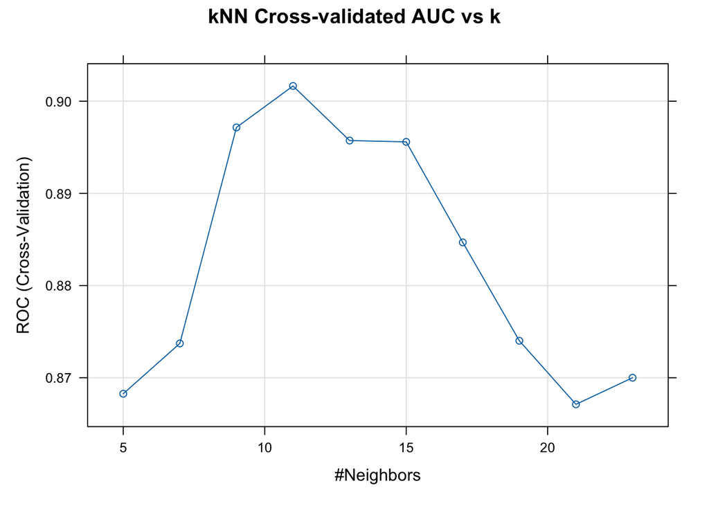

```r
# Plot ROC vs k
plot(knn_model, main = "kNN Cross-validated AUC vs k")
```

From the model summary above, we choose our best `k=11`.

## Model Performance Evaluation

```r
# Extract predictions from best-tuned model
best_knn_pred <- knn_model$pred %>%
  filter(k == knn_model$bestTune$k)

# Generate confusion matrix using cross-validated predictions
conf_matrix_knn <- confusionMatrix(
  data = best_knn_pred$pred,
  reference = best_knn_pred$obs,
  positive = "Yes"
)

print(conf_matrix_knn)
```

```
## Confusion Matrix and Statistics
##
##           Reference
## Prediction  No Yes
##        No    9   2
##        Yes  30 289
##
##                Accuracy : 0.903
##                  95% CI : (0.8659, 0.9327)
##     No Information Rate : 0.8818
##     P-Value [Acc > NIR] : 0.1325
##
##                   Kappa : 0.3249
##
##  Mcnemar's Test P-Value : 1.815e-06
##
##             Sensitivity : 0.9931
##             Specificity : 0.2308
##          Pos Pred Value : 0.9060
##          Neg Pred Value : 0.8182
##              Prevalence : 0.8818
##          Detection Rate : 0.8758
##    Detection Prevalence : 0.9667
##       Balanced Accuracy : 0.6119
##
##        'Positive' Class : Yes
##
```

The kNN model was trained using 10-fold cross-validation, with automatic tuning over a range of k values. The optimal number of neighbors was selected at `k=11`, based on the highest ROC=~`0.90` .

Evaluation using the best model revealed Sensitivity=`0.99`, Specificity = `0.23`, as shown in the confusion matrix.

## ROC Curve and AUC

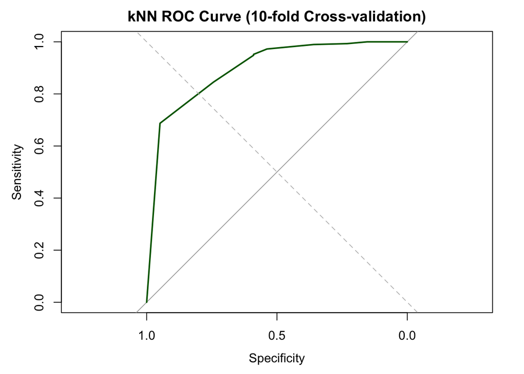

```r
# Compute ROC curve for best model
roc_knn <- roc(
  response = best_knn_pred$obs,
  predictor = best_knn_pred$Yes,    # Probability of class "Yes"
  levels = c("No", "Yes")
)

# Plot ROC curve
plot(roc_knn,
     col = "darkgreen",
     lwd = 2,
     main = "kNN ROC Curve (10-fold Cross-validation)")
abline(a = 0, b = 1, lty = 2, col = "gray")
```

```r
# Output AUC value
auc(roc_knn)
```

```
## Area under the curve: 0.8958
```

The ROC curve confirms strong discriminative power, with an AUC of `0.8958`.

# Comparison between RF-tree and kNN

Now, we put key performance values of random forest tree and kNN together.

```r
# Extract best predictions from each model
rf_pred_best <- tree.rf$pred %>%
  filter(mtry == tree.rf$bestTune$mtry)

knn_pred_best <- knn_model$pred %>%
  filter(k == knn_model$bestTune$k)

# Compute confusion matrices
rf_conf <- confusionMatrix(rf_pred_best$pred, rf_pred_best$obs, positive = "Yes")
knn_conf <- confusionMatrix(knn_pred_best$pred, knn_pred_best$obs, positive = "Yes")

# Build comparison table
comparison <- tibble::tibble(
  Model = c("Random Forest", "kNN"),
  ROC = c(
    max(tree.rf$results$ROC),
    max(knn_model$results$ROC)
  ),
  Sensitivity = c(
    rf_conf$byClass["Sensitivity"],
    knn_conf$byClass["Sensitivity"]
  ),
  Specificity = c(
    rf_conf$byClass["Specificity"],
    knn_conf$byClass["Specificity"]
  )
)

# Round and display
comparison %>%
  mutate(across(where(is.numeric), round, 3)) %>%
  kable(caption = "Cross-validated Performance of Random Forest and kNN (based on actual predictions)")
```

Cross-validated Performance of Random Forest and kNN (based on actual predictions)

| Model | ROC | Sensitivity | Specificity |
| --- | --- | --- | --- |
| Random Forest | 0.979 | 1.000 | 0.385 |
| kNN | 0.902 | 0.993 | 0.231 |

In contrast, the kNN model showed slightly lower sensitivity (`0.99`) and lower specificity (`0.23`), meaning it was both slightly less accurate in detecting Okataina and more prone to incorrectly labeling non-Okataina samples as Okataina. Despite the minor drop in recall, the model appears to assign the Okataina label more freely, which increases the risk of false positives.

Given our earlier emphasis on specificity, Random Forest may be preferable.

# Discussion

## Threshold Chosen by Youden Index(Specificity Concern Improvement)

To solve the rf-tree’s low specificity problem, we could manually adjust the classification threshold to increase our confidence in positive predictions.

By default, classification models assign the “Yes” label (i.e., positive class) when the predicted probability exceeds 0.5. However, when specificity is prioritized—such as in this geological classification task, where false positives may lead to misinterpretation of provenance—it is advisable to raise this threshold. Doing so makes the model more conservative in assigning the “Yes” class, thereby reducing the false positive rate and improving specificity.

This approach represents a post-hoc calibration technique where we trade off sensitivity for higher specificity. We can identify an optimal threshold by evaluating metrics such as the ROC curve, precision-recall tradeoff, or maximizing the Youden index (sensitivity + specificity - 1).

```r
# Define threshold values to evaluate
thresholds <- seq(0.1, 0.9, by = 0.05)

# Initialize empty results frame
youden_df <- data.frame()

# Loop over thresholds to compute sensitivity, specificity, and Youden index
for (t in thresholds) {
  pred_label <- ifelse(rf_pred_best$Yes > t, "Yes", "No") %>%
    factor(levels = c("No", "Yes"))

  cm <- confusionMatrix(pred_label, rf_pred_best$obs, positive = "Yes")

  sens <- cm$byClass["Sensitivity"]
  spec <- cm$byClass["Specificity"]
  youden <- sens + spec - 1

  youden_df <- rbind(youden_df, data.frame(
    Threshold = t,
    Sensitivity = round(sens, 3),
    Specificity = round(spec, 3),
    YoudenIndex = round(youden, 3)
  ))
}

# Show table
youden_df
```

|  | Threshold | Sensitivity | Specificity | YoudenIndex |
| --- | --- | --- | --- | --- |
| Sensitivity | 0.10 | 1.000 | 0.000 | 0.000 |
| Sensitivity1 | 0.15 | 1.000 | 0.000 | 0.000 |
| Sensitivity2 | 0.20 | 1.000 | 0.051 | 0.051 |
| Sensitivity3 | 0.25 | 1.000 | 0.077 | 0.077 |
| Sensitivity4 | 0.30 | 1.000 | 0.103 | 0.103 |
| Sensitivity5 | 0.35 | 1.000 | 0.128 | 0.128 |
| Sensitivity6 | 0.40 | 1.000 | 0.231 | 0.231 |
| Sensitivity7 | 0.45 | 1.000 | 0.359 | 0.359 |
| Sensitivity8 | 0.50 | 1.000 | 0.385 | 0.385 |
| Sensitivity9 | 0.55 | 0.997 | 0.538 | 0.535 |

[output cut: 7 more lines]

```r
# Get the top 5 thresholds with the highest Youden Index
top5_youden <- youden_df %>%
  arrange(desc(YoudenIndex)) %>%
  head(5)

# Show the top 5 thresholds
top5_youden
```

|  | Threshold | Sensitivity | Specificity | YoudenIndex |
| --- | --- | --- | --- | --- |
| Sensitivity14 | 0.80 | 0.948 | 0.897 | 0.846 |
| Sensitivity13 | 0.75 | 0.973 | 0.872 | 0.844 |
| Sensitivity15 | 0.85 | 0.890 | 0.923 | 0.813 |
| Sensitivity12 | 0.70 | 0.986 | 0.795 | 0.781 |
| Sensitivity16 | 0.90 | 0.766 | 0.974 | 0.741 |

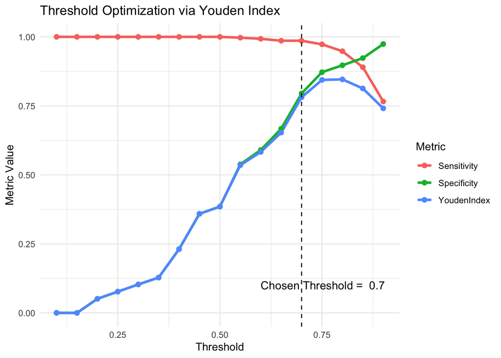

To identify the optimal decision threshold, we plotted sensitivity, specificity, and the Youden Index across a range of thresholds from 0.1 to 0.9. The curve shows how increasing the threshold improves specificity while reducing sensitivity.

The Youden Index peaks at a threshold of 0.75 and 0.80, suggesting these provide the best trade-off between true positive and true negative rates. This visualization supports threshold tuning as a post-hoc calibration method when the default cutoff (0.5) does not align with domain-specific priorities.

However, it is not always realistic to choose the threshold value at the peak of the Youden Index, considering that real-world data distributions vary. By experiment couple times, we set our threshold at 0.70.

## Confusion Matrix @ Threshold = 0.70

```r
# Manually set threshold = 0.70
threshold <- 0.70

# Classify predictions based on threshold
rf_pred_best$custom_pred <- ifelse(rf_pred_best$Yes > threshold, "Yes", "No") %>%
  factor(levels = c("No", "Yes"))

# Compute confusion matrix
cm_80 <- confusionMatrix(rf_pred_best$custom_pred, rf_pred_best$obs, positive = "Yes")
print(cm_80)
```

```
## Confusion Matrix and Statistics
##
##           Reference
## Prediction  No Yes
##        No   31   4
##        Yes   8 287
##
##                Accuracy : 0.9636
##                  95% CI : (0.9373, 0.9811)
##     No Information Rate : 0.8818
##     P-Value [Acc > NIR] : 1.239e-07
##
##                   Kappa : 0.8174
##
##  Mcnemar's Test P-Value : 0.3865
##
##             Sensitivity : 0.9863
##             Specificity : 0.7949
##          Pos Pred Value : 0.9729
##          Neg Pred Value : 0.8857
##              Prevalence : 0.8818
##          Detection Rate : 0.8697
##    Detection Prevalence : 0.8939
##       Balanced Accuracy : 0.8906
##
##        'Positive' Class : Yes
##
```

## ROC Curve with Threshold Marker

[figure not shown]

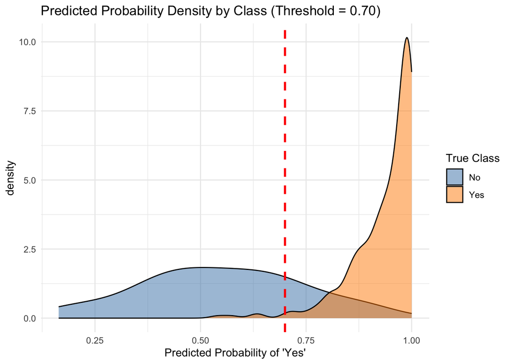

Using a manually selected threshold of `0.70`, we recalculated the classification results for the Random Forest model. This threshold yielded a specificity of `0.79` and a sensitivity of `0.99`—providing a strong balance while prioritizing low false positive rates.

# Final Prediction on Unlabeled Data with Random Forest (threshold = 0.70)

```r
# Step 1: Remove rows with missing values from the unlabeled dataset
rocks_unlabelled_clean <- na.omit(rocks_unlabelled)

# Step 2: Standardize the predictors using the same model from training
rocks_unlabelled_scaled <- predict(preproc_knn, rocks_unlabelled_clean)

# Step 3: Predict class probabilities using the trained Random Forest model
rf_probs <- predict(tree.rf, newdata = rocks_unlabelled_scaled, type = "prob")

# Step 4: Apply threshold = 0.70 to assign class labels
rf_pred_class <- ifelse(rf_probs$Yes > 0.70, "Okataina", "Not Okataina")

# Step 5: Combine results with predicted class and probability
rf_pred_result <- rocks_unlabelled_clean %>%
  mutate(
    Predicted_Source = rf_pred_class,
    Probability_Okataina = round(rf_probs$Yes, 3)
  )

# Step 6: View first few predictions
rf_pred_result[, c("Predicted_Source", "Probability_Okataina")]
```

| Predicted_Source | Probability_Okataina |
| --- | --- |
| Okataina | 0.722 |
| Okataina | 0.722 |
| Okataina | 0.722 |
| Okataina | 0.722 |
| Okataina | 0.722 |
| Okataina | 0.722 |
| Not Okataina | 0.632 |
| Okataina | 0.722 |
| Okataina | 0.722 |
| Okataina | 0.722 |

[output cut: 18 more lines]

## **Predicted Class Distribution (Count of “Okataina”)**

```r
# Count predicted categories
table(rf_pred_result$Predicted_Source)
```

```
##
## Not Okataina     Okataina
##            7           21
```

```r
# Show proportion
prop.table(table(rf_pred_result$Predicted_Source))
```

```
##
## Not Okataina     Okataina
##         0.25         0.75
```

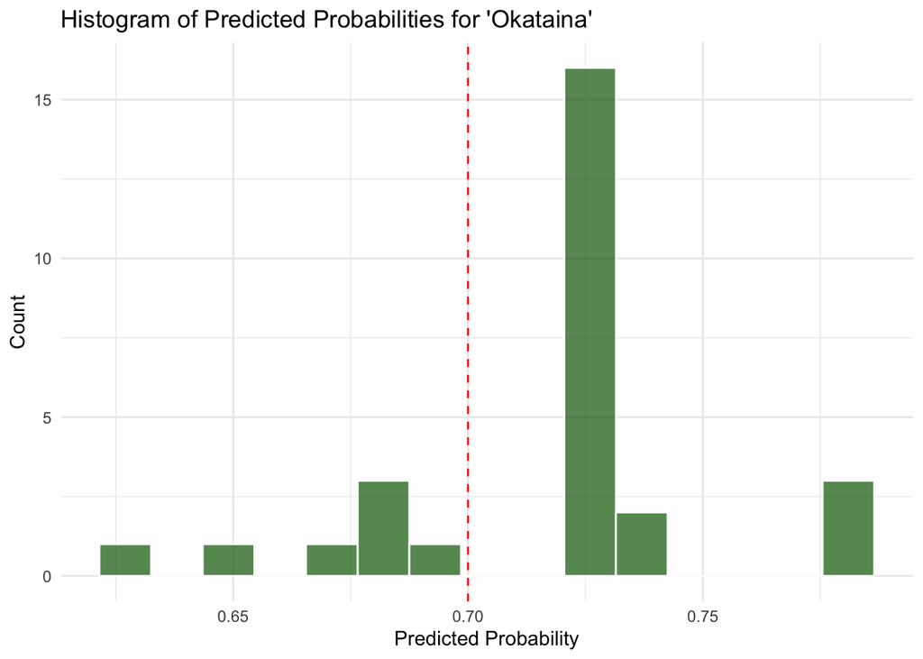

The histogram of predicted probabilities indicates the confidence spread, while the sorted bar chart clearly identifies which samples have the strongest predicted likelihood of being from Okataina. These visualizations support interpretation and downstream selection of high-confidence samples.

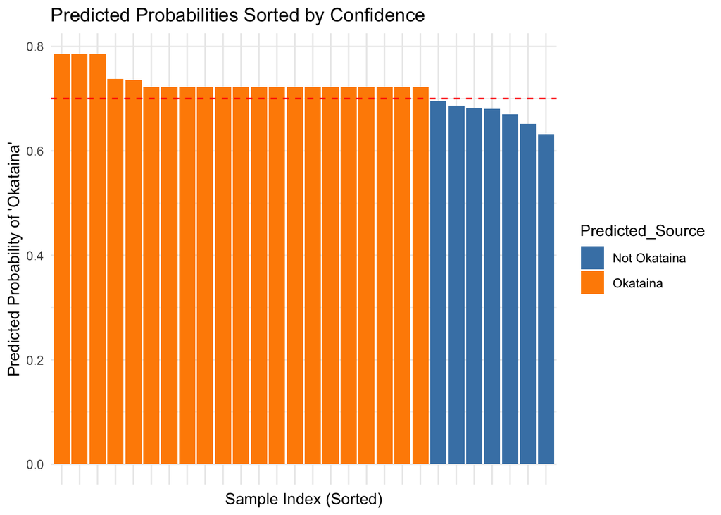

## Limitations of the Random Forest Tree

1. Overfitting Risk on Imbalanced Data  
   The dataset exhibits strong class imbalance, with over 88% of samples labelled as “Okataina”. Although RF can handle imbalance better than single trees, the model may still overfit to the majority class, leading to inflated accuracy and potentially low recall on minority classes.
2. Low Specificity in Default Settings  
   Without manual threshold tuning, the RF model showed near-perfect sensitivity but very low specificity (≈ 0.38). This behavior indicates that the model tends to over-predict the positive class, which could reduce reliability in negative class detection (i.e., identifying non-Okataina rocks).
3. Interpretability and Decision Transparency  
   Despite being more interpretable than neural networks, RF is still an ensemble of many deep trees. Understanding individual decision paths or explaining why a specific rock was classified as “Okataina” remains difficult without post-hoc analysis (e.g., SHAP values).
4. Sensitivity to Input Noise and Missing Data  
   During prediction on the unlabeled dataset, several samples had to be removed due to missing values. RF does not natively handle missing values unless specifically engineered. This can limit robustness in real-world scenarios where geochemical data is often incomplete.
5. Fixed Feature Importance  
   The model assumes all features are equally useful unless told otherwise. In geochemical datasets, some elements may be highly collinear or irrelevant. Without embedded feature selection, RF may be vulnerable to redundancy or noise in predictors.

While Random Forest is a powerful and flexible classifier, its performance in this case required manual calibration (e.g., threshold tuning) to meet domain-specific goals such as minimizing false positives. For broader deployment or automated applications, additional safeguards—such as feature selection, uncertainty quantification, and external validation—may be necessary to ensure robust generalization.

# Question B: **Clustering seeds**